# Datavis with ggplot2

The [ggplot2](http://docs.ggplot2.org/current/) package is a plotting system for R, based on the grammar of graphics, which tries to take the good parts of base and lattice graphics and none of the bad parts.

#### Overview

1. Introduction: Plotting with ggplot2
   - A simple function: qplot
   - A robust function: ggplot
2. Scatterplot
3. Faceting
   - Facet wrap
   - Facet grid
4. Title and axis
5. Histograms
6. Boxplots and violin plots
7. Output and saving

#### 1. Introduction: Plotting with ggplot2

First, install and load the ggplot2 package

```r
install.packages("ggplot2")
library(ggplot2)
```

For this session, we will explore the `iris` data that is already pre-loaded in R.

```r
head(iris)
```

| Sepal.Length | Sepal.Width | Petal.Length | Petal.Width | Species |
| --- | --- | --- | --- | --- |
| 5.1 | 3.5 | 1.4 | 0.2 | setosa |
| 4.9 | 3.0 | 1.4 | 0.2 | setosa |
| 4.7 | 3.2 | 1.3 | 0.2 | setosa |
| 4.6 | 3.1 | 1.5 | 0.2 | setosa |
| 5.0 | 3.6 | 1.4 | 0.2 | setosa |
| 5.4 | 3.9 | 1.7 | 0.4 | setosa |

You can read about the data by typing

```r
?iris
```

**1.1. A simple function: qplot**

The general formula is `qplot(x, y, ...)`. To produce a basic scatter plot, type

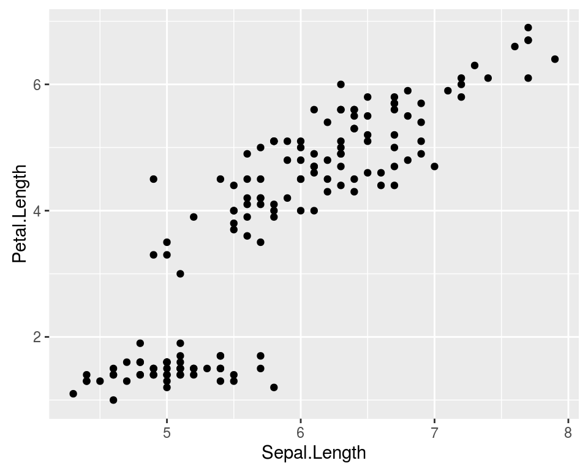

```r
qplot(x=Sepal.Length, y=Petal.Length, data=iris)
```

Adding color per species and size depending of petals width

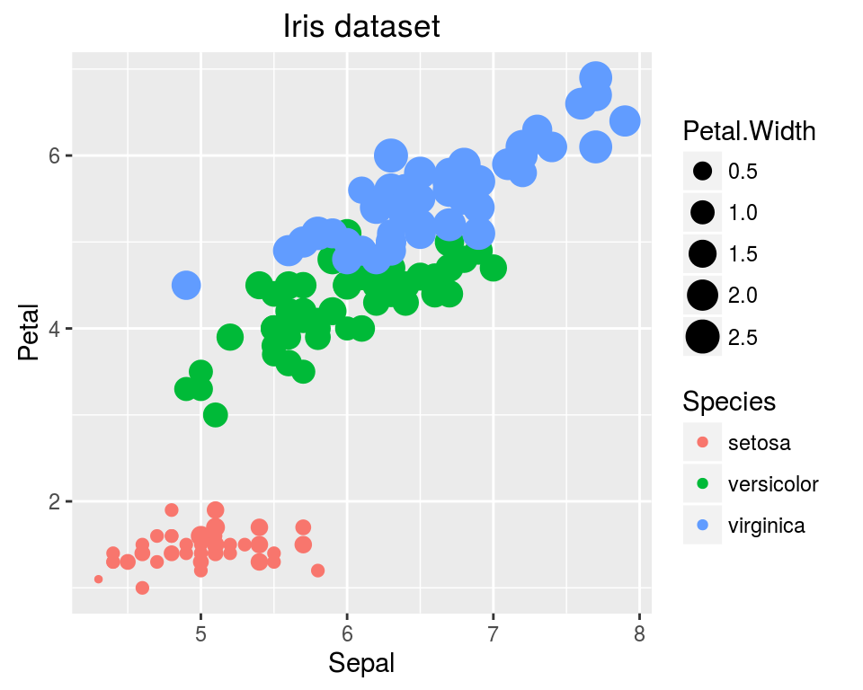

```r
qplot(Sepal.Length, Petal.Length, data=iris,
      color=Species, size=Petal.Width,
      xlab="Sepal", ylab="Petal", main="Iris dataset")
```

We also add a title and labels for the x and y-axis, using `main`, `xlab`and `ylab`.

To start at 0 for the y-axis: add `qplot(...,ylim=c(0,35))`  
This set lower and upper bounds for y axis.  
You can do the same for the x-axis

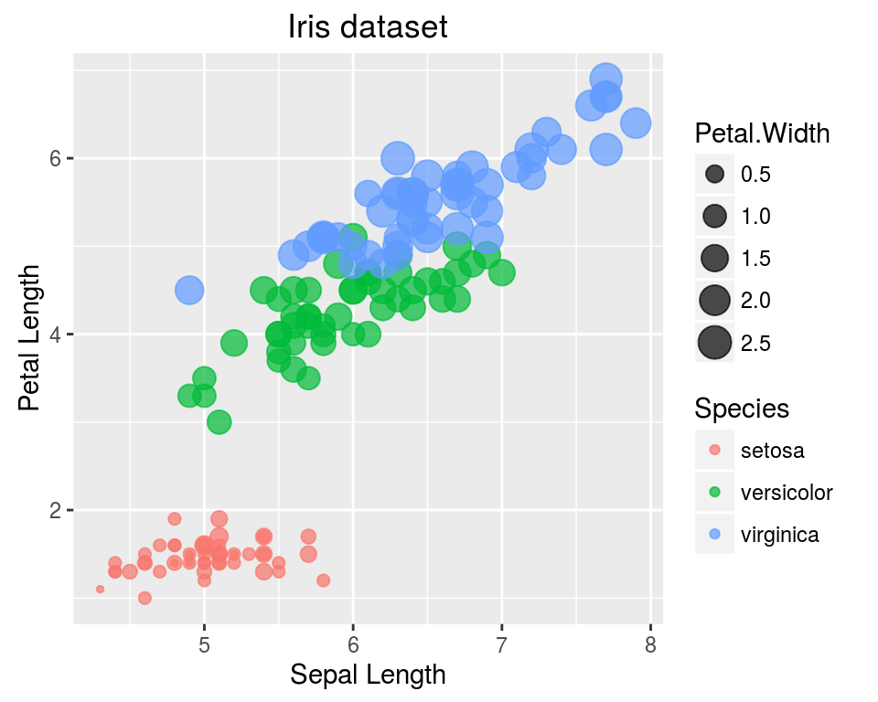

```r
qplot(Sepal.Length, Petal.Length, data=iris,
      color=Species, size=Petal.Width, alpha=I(0.7),
      xlab="Sepal Length", ylab="Petal Length", main="Iris dataset")
```

By setting the alpha of each point to 0.7, we reduce the effects of overplotting.

**1.2. A robust function: ggplot**

General formula:  
`ggplot(data, aes(x,y)) + geom_*()`  
ggplot begins a plot that you finish by adding layers to, using `geom()`. ggplot provides more control than qplot().

- *aes*: aesthetic, visual properties of the graph
  - *options aes*: color, fill, shape, size
- *geom*: graphical property
  - geom_line; geom_bar; geom_histogram
  - geom_chart; geom_hex, geom_c(point,line) etc. You can specify for each geom the aesthetic mappings, and a default stat and position adjustment: `geom_*(aes(color=, fill=, size=....))`
- *additional elements* :
  - You can add a smoothing trend : + `geom_smooth (method="lm")`
  - You can change the background (Themes): `+ theme_bw()`, `+theme_classic()

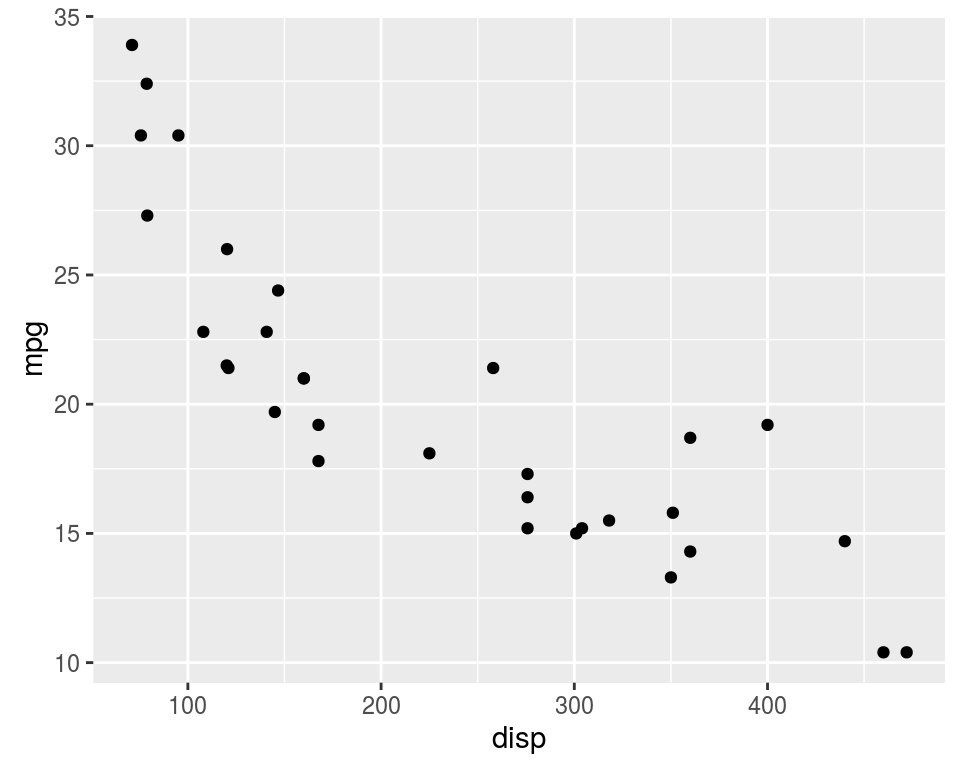

```r
ggplot(mtcars,aes(x=disp,y=mpg))+ geom_point()
```

From now on, we will only work using ggplot.

Back to top

#### 2. Scatterplot

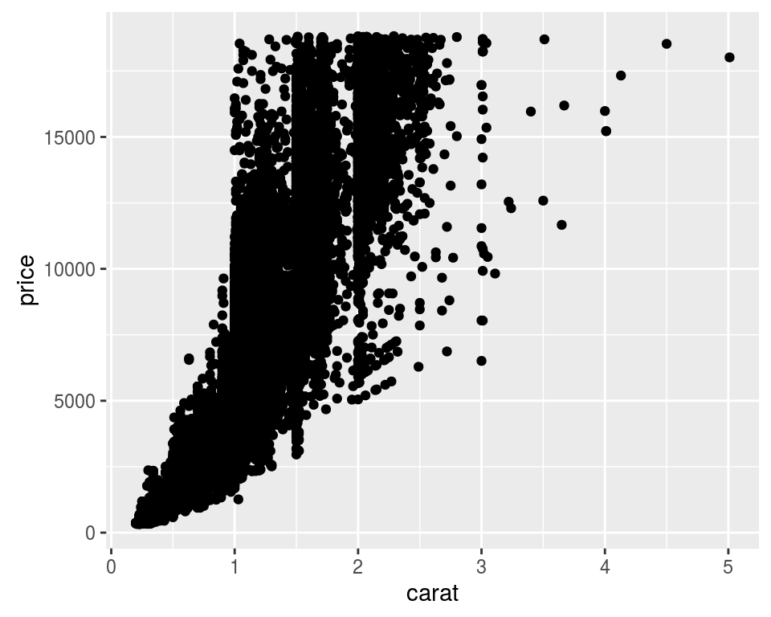

```r
ggplot(diamonds, aes(x=carat, y=price)) + geom_point()
```

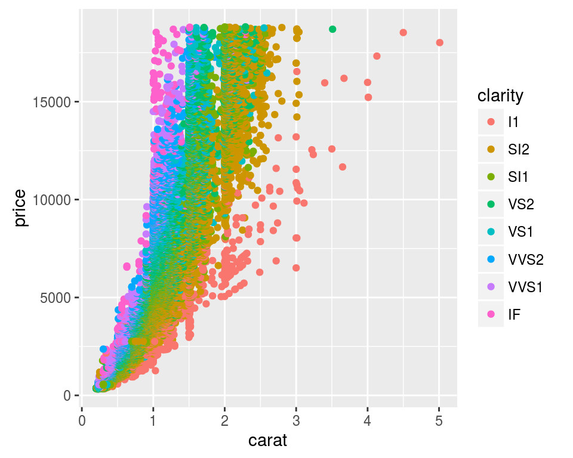

```r
ggplot(diamonds, aes(x=carat, y=price, color=clarity)) + geom_point()
```

Adding color: the color of the points is determined by the clarity of the diamonds.

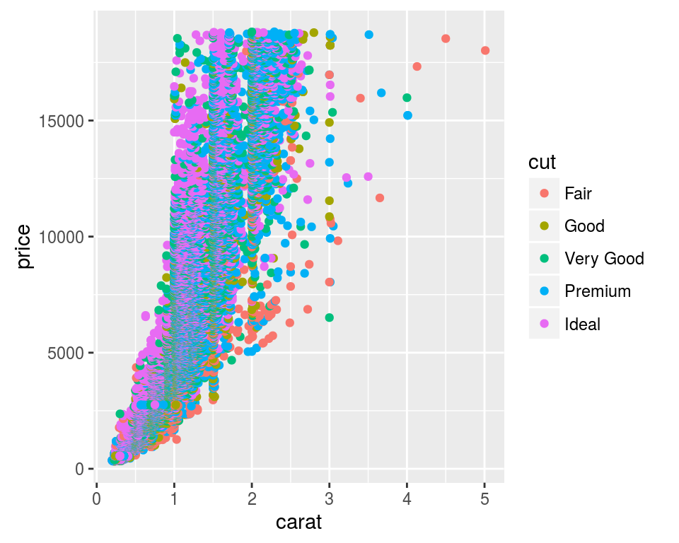

```r
ggplot(diamonds, aes(x=carat, y=price, color=cut)) + geom_point()
```

Here we changed the color by the parameter “cut” of the dataset diamonds.

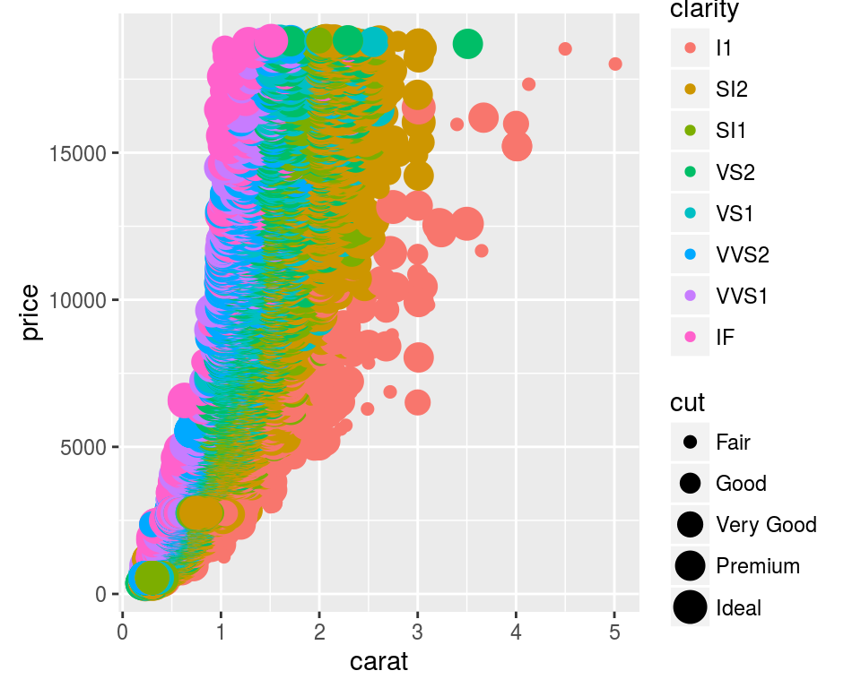

```r
ggplot(diamonds, aes(x=carat, y=price, color=clarity, size=cut)) + geom_point()
```

Here we changed the size of the points according to the parameter cut.

Back to top

#### 3. Faceting

- Divide your plot up into multiple plots, one for each level.
- `facet_*()` function

**3.1. Facet wrap**

Write a tilde (~), and then the attribute we would like to divide the plots by (here “clarity”)

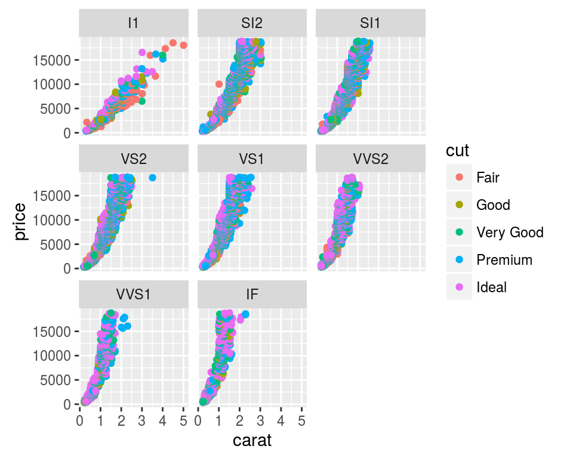

```r
ggplot(diamonds, aes(x=carat, y=price, color=cut)) + geom_point() + facet_wrap(~ clarity)
```

**3.2. Facet grid**

To divide your graph based on **two different attributes**: `facet_grid()`  
Here we could use `"color ~ clarity"`. The tilde (~) means “explained by.”

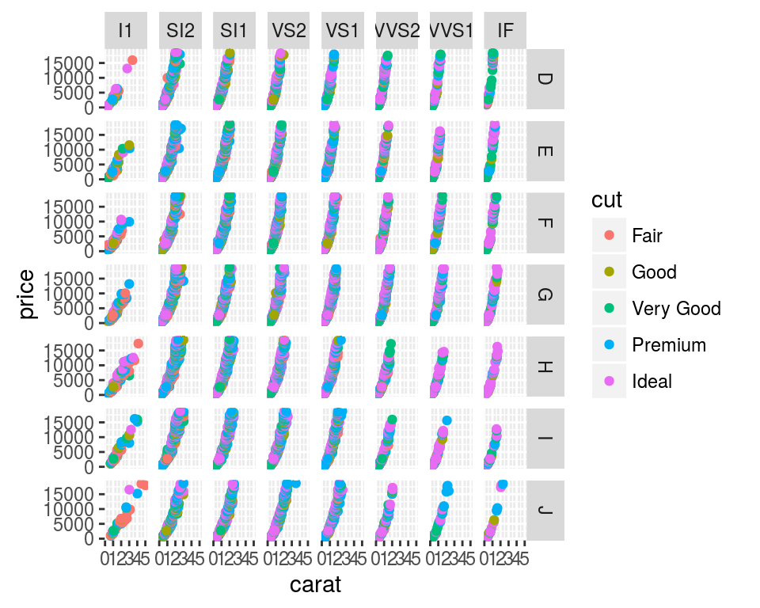

```r
ggplot(diamonds, aes(x=carat, y=price, color=cut)) + geom_point() + facet_grid(color ~ clarity)
```

Back to top

#### 4. Title and axis

Title: add to the end of the line of code `ggtile()`

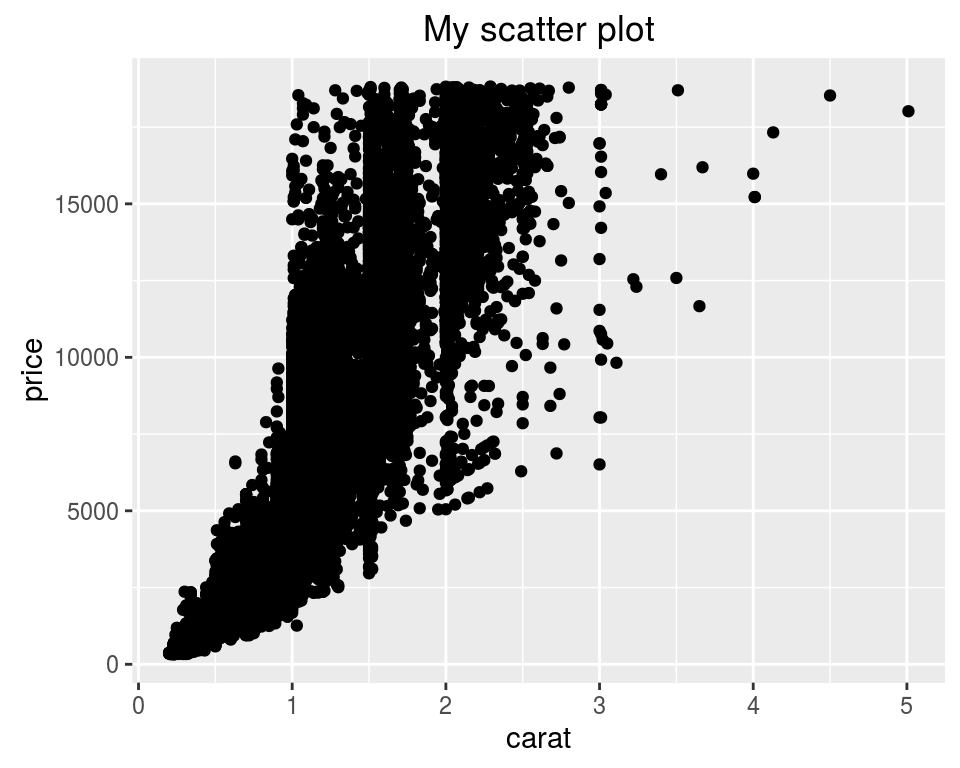

```r
ggplot(diamonds, aes(carat,price)) + geom_point() + ggtitle("My scatter plot")
```

Axis label: `xlab` and `ylab`

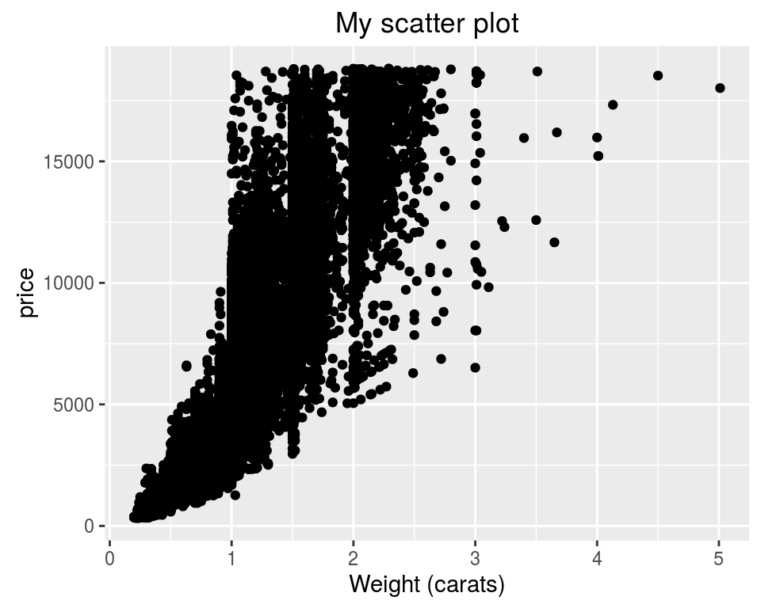

```r
ggplot(diamonds, aes(x=carat, y=price)) + geom_point() + ggtitle("My scatter plot") + xlab("Weight (carats)")
```

To limit the range of the x or the y axes: `xlim` or `ylim`

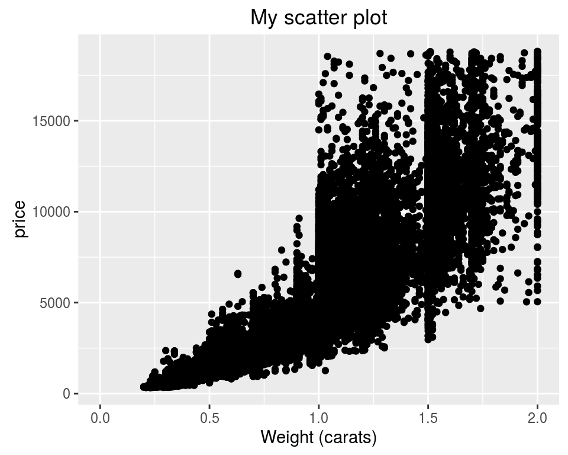

```r
ggplot(diamonds, aes(x=carat, y=price)) + geom_point() + ggtitle("My scatter plot") + xlab("Weight (carats)") + xlim(0, 2)
```

This code limits the diamonds weight from 0 to 2 carats.

Another possibility is to put one of the axes on a log scale. You can do this with the `scale_y_log10()` function:

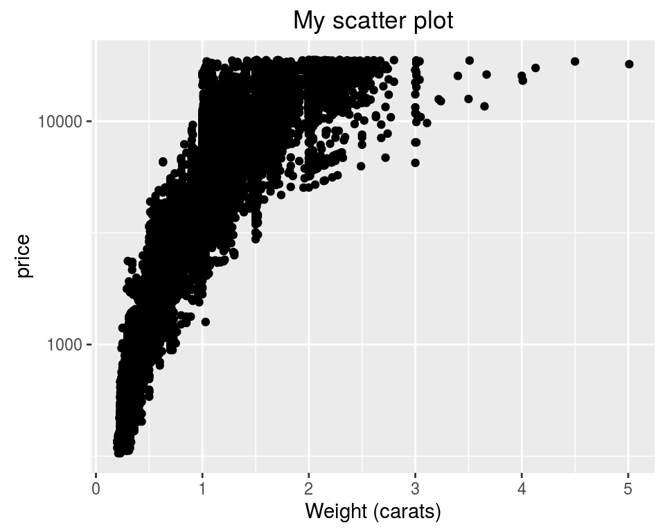

```r
ggplot(diamonds, aes(x=carat, y=price)) + geom_point() + ggtitle("My scatter plot") + xlab("Weight (carats)") + scale_y_log10()
```

Back to top

#### 5. Histograms

Using the data set diamonds, we visualize the density of the distribution of price:

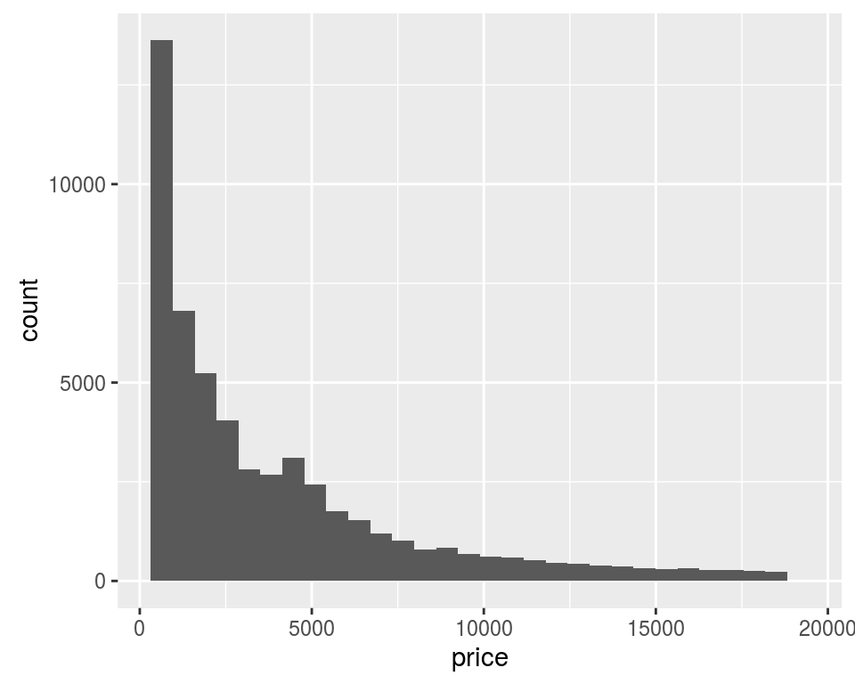

```r
ggplot(diamonds, aes(x=price)) + geom_histogram()
```

You can change the width of each bin as an option, using `binwidth` inside the `geom_histogram()` function:

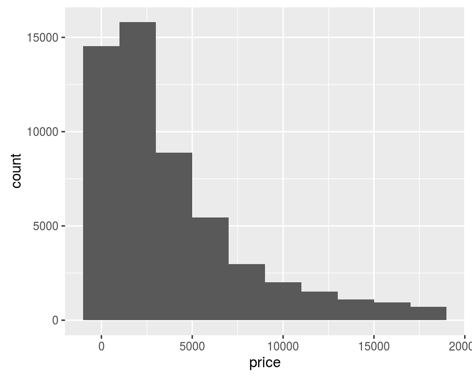

```r
ggplot(diamonds, aes(x=price)) + geom_histogram(binwidth=2000)
```

And we can add all the options that we used with a basci scatter plot. For instance, the `facet_wrap()` function:

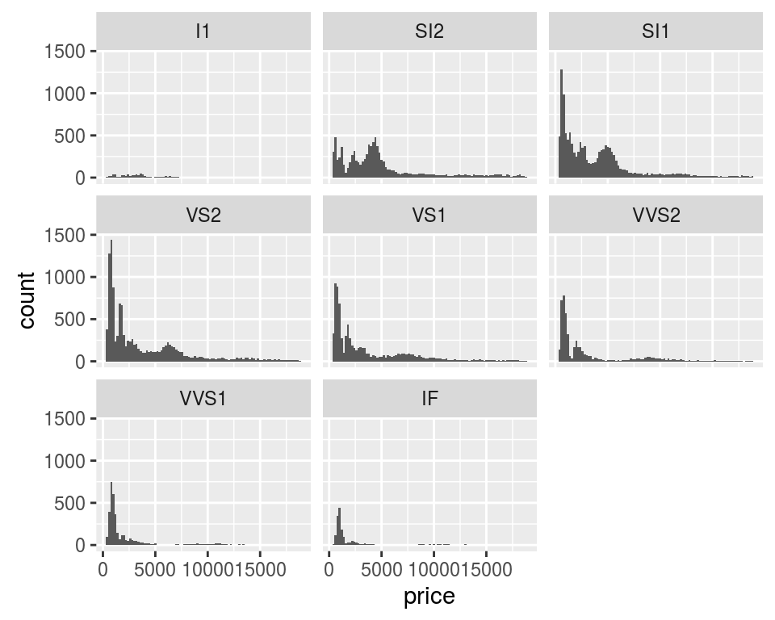

```r
ggplot(diamonds, aes(x=price)) + geom_histogram(binwidth=200) + facet_wrap(~ clarity)
```

Here, all the subplots share the same y-axis: this makes it hard to interpret the frequencies…  
Some subplots have far more points than others.

To have different y-axis for each subplot, add `scale="free_y"`

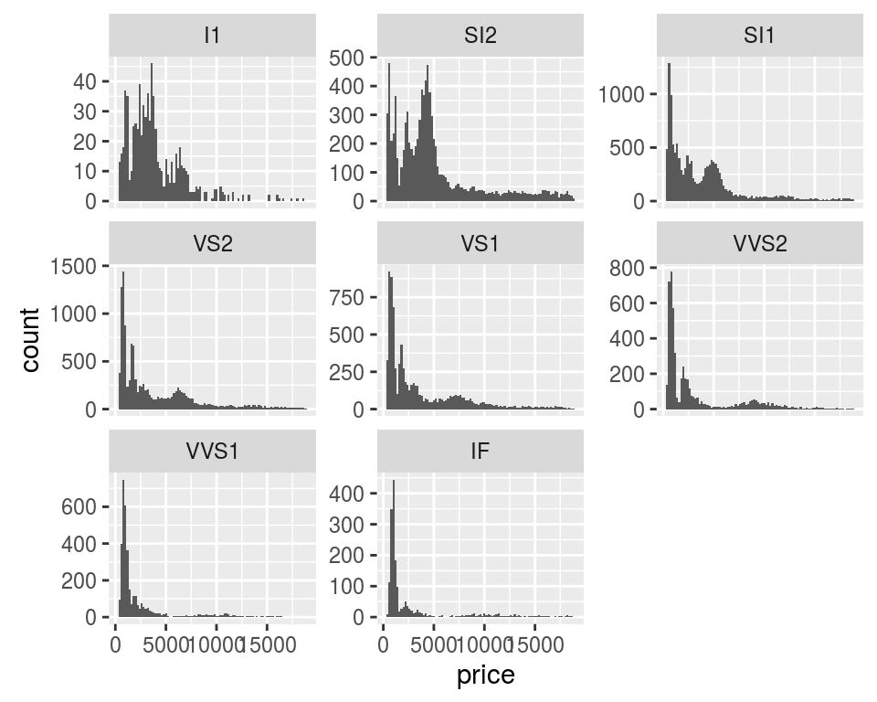

```r
ggplot(diamonds, aes(x=price)) + geom_histogram(binwidth=200) + facet_wrap(~ clarity, scale="free_y")
```

The same function can be used differentiating for the x-axis.

To make a **stacked histogram** based here on the clarity attribute: Try adding the `fill` aesthetic within the aesthetic of the `ggplot()` function.

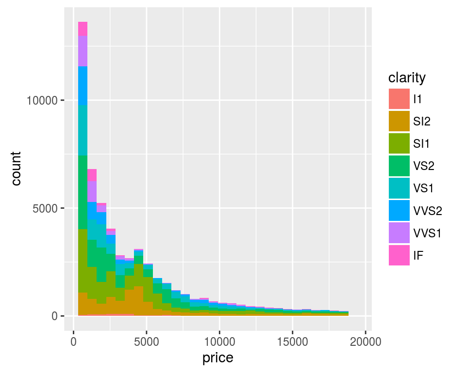

```r
ggplot(diamonds, aes(x=price, fill=clarity)) + geom_histogram()
```

Back to top

#### 6. Boxplots and violin plots

Boxplots are useful to compare multiple distributions. Compare the distribution of the price within each color using `geom_boxplot()`:

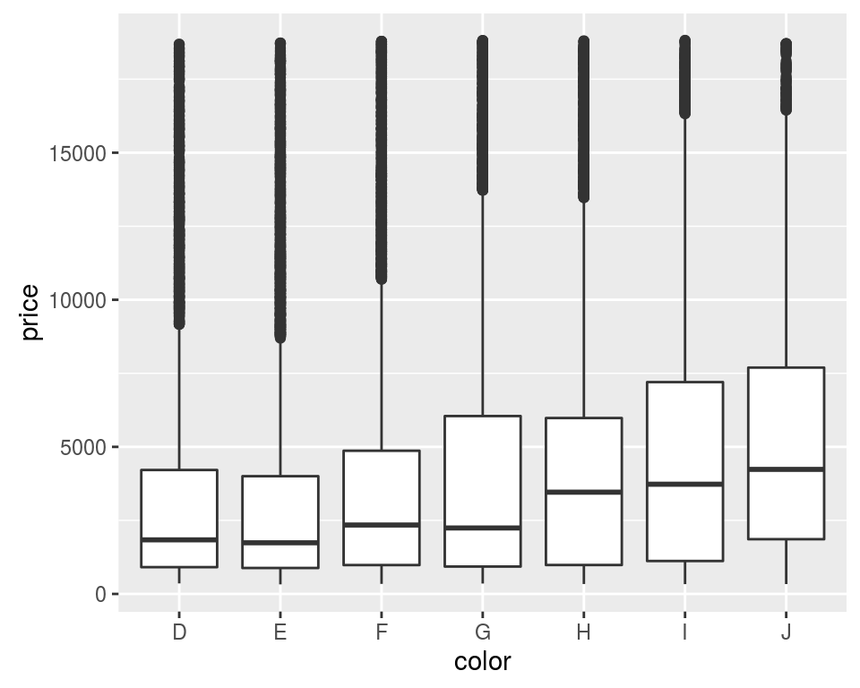

```r
ggplot(diamonds, aes(x=color, y=price)) + geom_boxplot()
```

Put the y-axis on a log scale: we get a better sense of how the distribution of price differs across multiple colors.

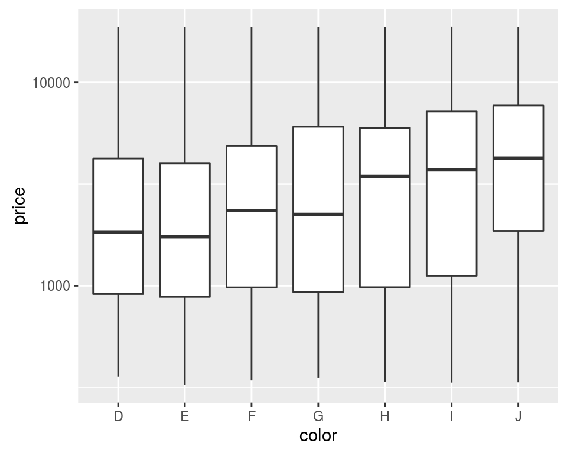

```r
ggplot(diamonds, aes(x=color, y=price)) + geom_boxplot() + scale_y_log10()
```

A box plot will always look like a square. We can instead view the distribution as a density using a “violin plot”.

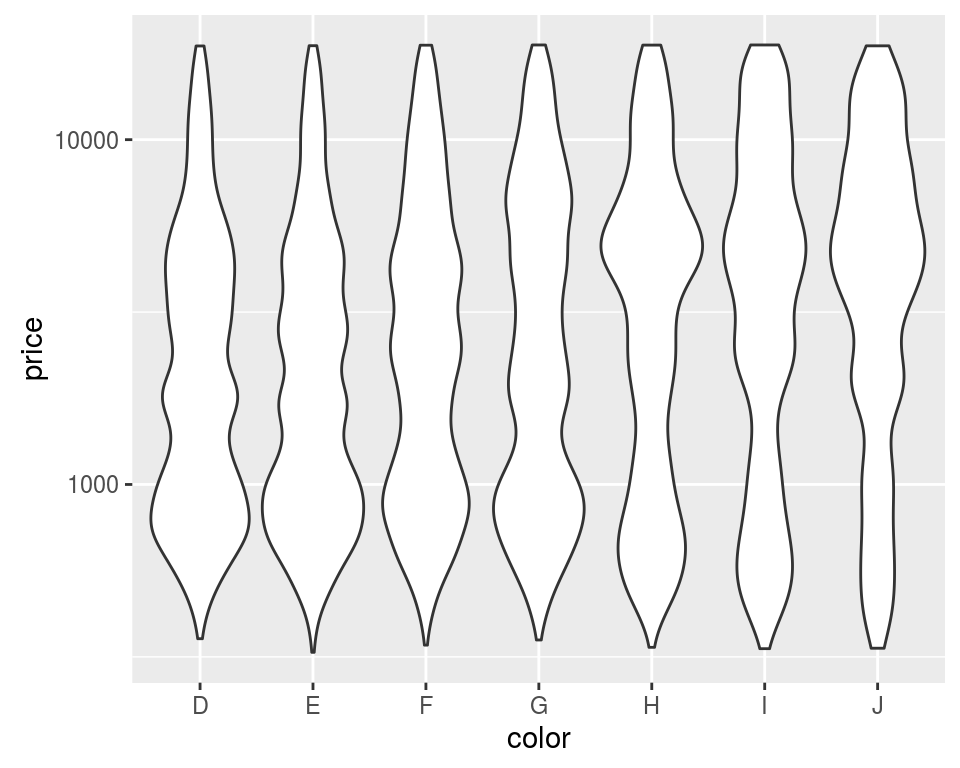

```r
ggplot(diamonds, aes(x=color, y=price)) + geom_violin() + scale_y_log10()
```

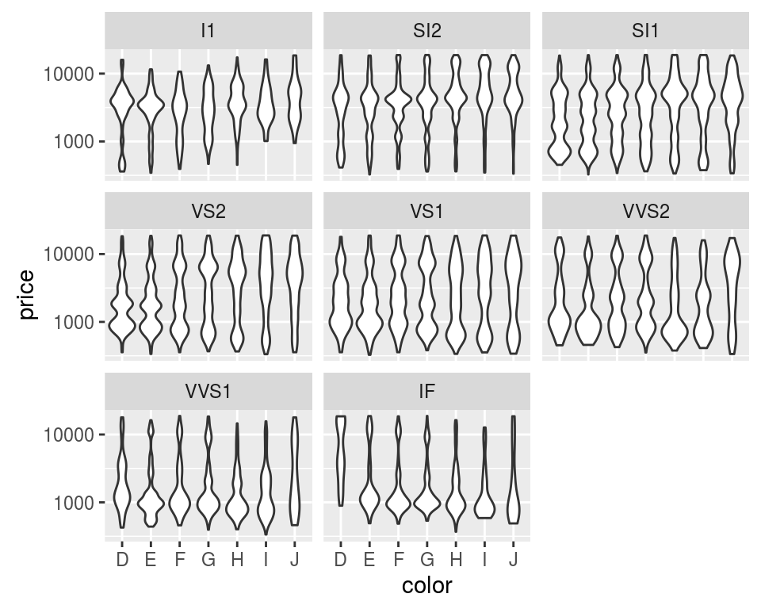

```r
ggplot(diamonds, aes(x=color, y=price)) + geom_violin() + scale_y_log10() + facet_wrap(~ clarity)
```

We used the `facet_wrap()` function to display multiple subplots.

Back to top

#### 7. Output and saving

Run your line of code and save it to a variable. For instance, call it p for plot:

```r
p = ggplot(diamonds, aes(x=carat, y=price)) + geom_point()
```

Save that plot to a file

```r
ggsave(filename="diamonds.png", p)  ## as a png
ggsave(filename="diamonds.pdf", p)  ## as a pdf
ggsave(filename="diamonds.jpeg", p) ## as a jpeg
```

One useful shortcut is that if you just displayed a plot, like in a line like this:

```r
ggplot(diamonds, aes(x=carat, y=price)) + geom_point()
ggsave("diamonds.png")
```

Then `ggsave()` will know to save that plot by default when you perform `ggsave` - you don’t even have to tell it which plot you’re saving.

Back to top